## Summary

The goal is to predict the manner in which they did the exercise. This is the “classe” variable in the training set.

## Exploratory analysis

As first step load and take a look to the dataset

```
## 'data.frame':    19622 obs. of  160 variables:
##  $ X                       : int  1 2 3 4 5 6 7 8 9 10 ...
##  $ user_name               : Factor w/ 6 levels "adelmo","carlitos",..: 2 2 2 2 2 2 2 2 2 2 ...
##  $ raw_timestamp_part_1    : int  1323084231 1323084231 1323084231 1323084232 1323084232 1323084232 1323084232 1323084232 1323084232 1323084232 ...
##  $ raw_timestamp_part_2    : int  788290 808298 820366 120339 196328 304277 368296 440390 484323 484434 ...
##  $ cvtd_timestamp          : Factor w/ 20 levels "02/12/2011 13:32",..: 9 9 9 9 9 9 9 9 9 9 ...
##  $ new_window              : Factor w/ 2 levels "no","yes": 1 1 1 1 1 1 1 1 1 1 ...
##  $ num_window              : int  11 11 11 12 12 12 12 12 12 12 ...
##  $ roll_belt               : num  1.41 1.41 1.42 1.48 1.48 1.45 1.42 1.42 1.43 1.45 ...
##  $ pitch_belt              : num  8.07 8.07 8.07 8.05 8.07 8.06 8.09 8.13 8.16 8.17 ...
##  $ yaw_belt                : num  -94.4 -94.4 -94.4 -94.4 -94.4 -94.4 -94.4 -94.4 -94.4 -94.4 ...
##  $ total_accel_belt        : int  3 3 3 3 3 3 3 3 3 3 ...
##  $ kurtosis_roll_belt      : Factor w/ 397 levels "","-0.016850",..: 1 1 1 1 1 1 1 1 1 1 ...
##  $ kurtosis_picth_belt     : Factor w/ 317 levels "","-0.021887",..: 1 1 1 1 1 1 1 1 1 1 ...
##  $ kurtosis_yaw_belt       : Factor w/ 2 levels "","#DIV/0!": 1 1 1 1 1 1 1 1 1 1 ...
```

[output cut: 86 more lines]

There are 19622 cases and 159 potential predictors , so we should proceed with some data cleaning and feature reduction, given lot of them seems to be NA.

### Cleanup and Feature selection

Looking at the sample, some consideration can be done. We could cleanup the variable clearly numeric that has been intrepreted as factor and the “auxiliary” variables, like the ones timestamp and names of the people

**possible assumption:** having a variable containing few distinct real number and not a distribution of them is an index of poor quality of data or that the variable is not meanigful. Ex: kurtosis_roll_belt  
Using the *nearZeroVar* of caret package would do the job of removing such low-variation variables.

After cleanup and removal of the timestamp and names variables we have 95 variables left. Perform usual train & set data separation

## Fitting Data

Jump directly on the cart application of the tree, to get some insight. Ignore the NA and rereieve the importance of the variables for further consideration

```r
har.sample.rf = randomForest(classe ~ ., data =training.Sample,importance=TRUE,na.action=na.omit)
har.sample.rf
```

```
##
## Call:
##  randomForest(formula = classe ~ ., data = training.Sample, importance = TRUE,      na.action = na.omit)
##                Type of random forest: classification
##                      Number of trees: 500
## No. of variables tried at each split: 9
##
##         OOB estimate of  error rate: 21.45%
## Confusion matrix:
##    A  B  C  D  E class.error
## A 65  6  2  1  1   0.1333333
## B 13 40  0  1  1   0.2727273
## C  8  1 42  1  0   0.1923077
## D  8  1  5 32  1   0.3191489
## E  2  7  1  2 48   0.2000000
```

```r
summary(har.sample.rf$err.rate)
```

```
##       OOB               A                B                C
##  Min.   :0.1938   Min.   :0.1200   Min.   :0.2000   Min.   :0.1731
##  1st Qu.:0.2042   1st Qu.:0.1333   1st Qu.:0.2545   1st Qu.:0.1923
##  Median :0.2076   Median :0.1333   Median :0.2727   Median :0.2115
##  Mean   :0.2238   Mean   :0.1498   Mean   :0.2771   Mean   :0.2187
##  3rd Qu.:0.2249   3rd Qu.:0.1467   3rd Qu.:0.3091   3rd Qu.:0.2308
##  Max.   :0.4788   Max.   :0.5769   Max.   :0.5417   Max.   :0.5000
##        D                E
##  Min.   :0.2766   Min.   :0.1667
##  1st Qu.:0.2979   1st Qu.:0.1833
##  Median :0.2979   Median :0.2000
##  Mean   :0.3159   Mean   :0.1993
##  3rd Qu.:0.3191   3rd Qu.:0.2000
##  Max.   :0.6538   Max.   :0.4259
```

Cross validation is done automatically by the randomForest fucntion(see documentation) The *err.rate* gives the vector error rates of the prediction on the input data, the i-th element being the (OOB) error rate for all trees up to the i-th  
Predict the values on the test sample and check manually the accuracy.

```r
har.sample.predict = predict(har.sample.rf, newdata=test.Sample, type="response")
t=table(predicted=har.sample.predict,observed=test.Sample[,"classe"])
```

```
##          observed
## predicted  A  B  C  D  E
##         A 34  1  3  1  0
##         B  0 20  3  2  3
##         C  0  1 11  1  0
##         D  0  1  1 18  1
##         E  0  1  0  0 15
```

Accuracy is 83.7606838%

## Additional Exploration

Search the be the most meaningful variables to be taken into account, using importance

```r
har.sample.rf.importance =data.frame(importance(har.sample.rf))
har.sample.rf.importance[which(har.sample.rf.importance$MeanDecreaseGini>5.5),]
```

```
##                           A         B         C         D        E
## avg_roll_belt      6.750912  5.571473  7.388070  7.998629 8.861269
## stddev_roll_belt   7.006369  8.419608  8.648040  9.815924 9.924861
## var_roll_belt      7.322283  7.607315  7.797324  9.419037 9.824657
## var_accel_dumbbell 7.288486 13.574801 12.839776  9.256723 4.565994
## avg_roll_dumbbell  8.191165  2.930724 13.600614 11.541639 2.210848
##                    MeanDecreaseAccuracy MeanDecreaseGini
## avg_roll_belt                  10.37299         5.978612
## stddev_roll_belt               11.09062         7.044877
## var_roll_belt                  10.99183         6.227953
## var_accel_dumbbell             15.90547         7.827134
## avg_roll_dumbbell              15.54121         7.860316
```

Try to use these variables: *avg_roll_belt, stddev_roll_belt, var_roll_belt, var_accel_dumbbell, avg_roll_dumbbell*  
to build a linear model or just check if the relation could be meaningful

```r
har.sample.lr=glm(classe~ avg_roll_belt+ stddev_roll_belt+ var_roll_belt+ var_accel_dumbbell+ avg_roll_dumbbell , data=training.Sample, family="binomial" ,na.action=na.omit)
summary(har.sample.lr)
```

```
##
## Call:
## glm(formula = classe ~ avg_roll_belt + stddev_roll_belt + var_roll_belt +
##     var_accel_dumbbell + avg_roll_dumbbell, family = "binomial",
##     data = training.Sample, na.action = na.omit)
##
## Deviance Residuals:
##     Min       1Q   Median       3Q      Max
## -2.2613  -1.3471   0.5601   0.9361   1.0731
##
## Coefficients:
##                      Estimate Std. Error z value Pr(>|z|)
## (Intercept)         0.5018195  0.2844080   1.764   0.0777 .
## avg_roll_belt       0.0001499  0.0025896   0.058   0.9539
## stddev_roll_belt   -0.3650154  0.6584397  -0.554   0.5793
## var_roll_belt       0.2341028  0.1949731   1.201   0.2299
## var_accel_dumbbell  0.2173358  0.0849640   2.558   0.0105 *
## avg_roll_dumbbell  -0.0015570  0.0022153  -0.703   0.4822
## ---
## Signif. codes:  0 '***' 0.001 '**' 0.01 '*' 0.05 '.' 0.1 ' ' 1
##
## (Dispersion parameter for binomial family taken to be 1)
##
##     Null deviance: 330.93  on 288  degrees of freedom
## Residual deviance: 284.17  on 283  degrees of freedom
##   (13448 observations deleted due to missingness)
## AIC: 296.17
##
## Number of Fisher Scoring iterations: 10
```

There is an high percentage of observation deleted is not reassuring. Only in one case a meaningful Z score appears showing a relevant significance.  
Plot it against the *classe* for the sake of curiosity

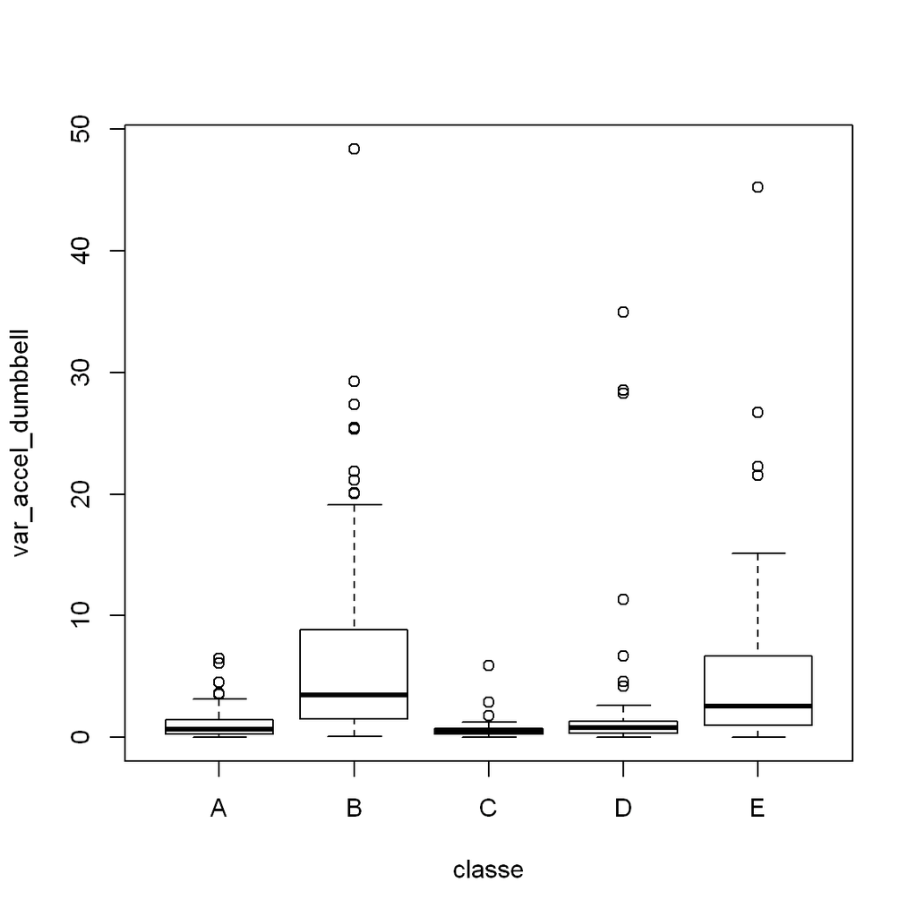